# Practical Machine Learning Assignment

Cherylyn Ee

6 October 2016

# Background

Devices such as Nike FuelBand, Fitbit are part of the quantified self movement ??? a group of enthusiasts who take measurements about themselves regularly to improve their health, to find patterns in their behavior, or because they are tech geeks. One thing that people regularly do is quantify how much of a particular activity they do, but they rarely quantify how well they do it. In this project, we will use data from accelerometers on the belt, forearm, arm, and dumbell of 6 participants to predict the manner in which participants did the exercise. We will use the “classe” variable in the data to predict and test on 20 test cases available in the test data set.

# Data Loading & Cleansing

The training data for this project is obtained from: https://d396qusza40orc.cloudfront.net/predmachlearn/pml-training.csv

The test data is obtained from: https://d396qusza40orc.cloudfront.net/predmachlearn/pml-testing.csv

```r
traindat <- read.csv("https://d396qusza40orc.cloudfront.net/predmachlearn/pml-training.csv")
testdat <- read.csv("https://d396qusza40orc.cloudfront.net/predmachlearn/pml-testing.csv")
library(caret)
library(knitr)
library(randomForest)
```

We partition the training data (70% training, 30% validation) for cross validation purposes.

```r
set.seed(131188)
inTrain <- createDataPartition(traindat$classe, p=0.7, list=FALSE)
training <- traindat[inTrain,]
testing <- traindat[-inTrain,]
dim(training); dim(testing)
```

```
## [1] 13737   160
```

```
## [1] 5885  160
```

By looking at the training data, we can notice variables with too many NA values, low variance or have no relevancy to predict classe. We will remove these variables as predictors

```r
# Remove too many NA variables
NAvar <- sapply(training, function(x) mean(is.na(x))) > 0.95
training <- training[, NAvar==FALSE]
testing <- testing[, NAvar==FALSE]
dim(training); dim(testing)
```

```
## [1] 13737    93
```

```
## [1] 5885   93
```

```r
# Remove Nearly Zero Variance variables
zerovar <- nearZeroVar(training)
training <- training[, -zerovar]
testing <- testing[, -zerovar]
dim(training); dim(testing)
```

```
## [1] 13737    59
```

```
## [1] 5885   59
```

```r
# Remove irrelevant variables
irrel <- grep("X|user_name|timestamp|num_window", names(training))
training <- training[,-irrel]
testing <- testing[, -irrel]
dim(training); dim(testing)
```

```
## [1] 13737    53
```

```
## [1] 5885   53
```

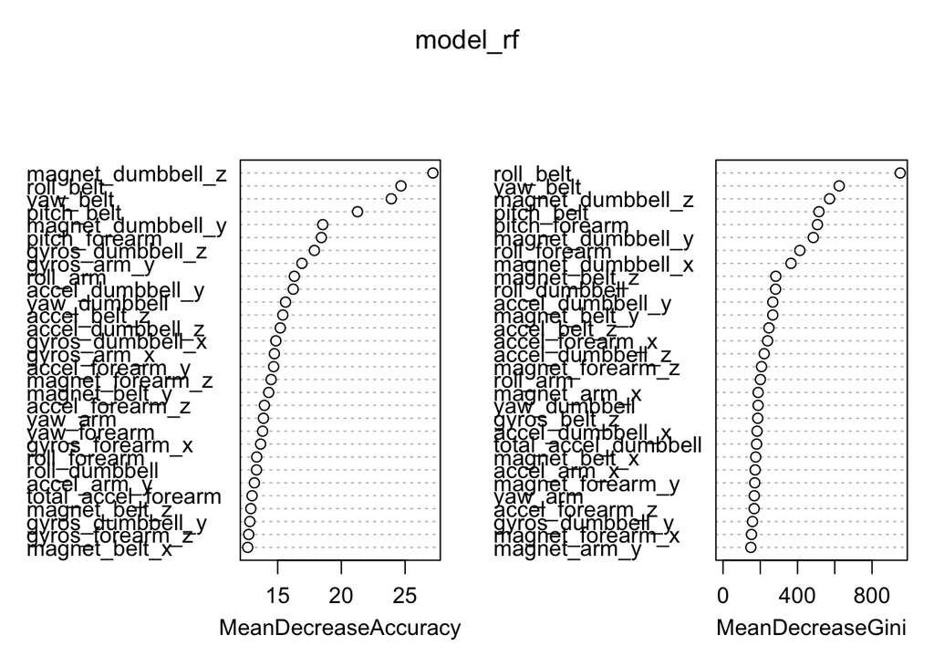

```r
set.seed(131188)
model_rf <- randomForest(classe ~ ., data=training, ntree = 100, importance = TRUE)
varImpPlot(model_rf, sort = TRUE)
```

From the we can choose the top 10 variables to simplify our model. Limiting the number of variables without sacrificing too much accuracy can ensure better interpretability of the model.

# Check correlation between predictors

Generally, attributes with an absolute correlation of 0.75 or higher is removed.

```r
correlationMatrix <- cor(training[,c("yaw_belt","roll_belt","accel_dumbbell_z","pitch_belt","magnet_dumbbell_z","magnet_dumbbell_y","pitch_forearm","accel_dumbbell_y","roll_arm","roll_forearm")])
which(abs(correlationMatrix)>0.75, arr.ind=TRUE)
```

```
##                   row col
## yaw_belt            1   1
## roll_belt           2   1
## yaw_belt            1   2
## roll_belt           2   2
## accel_dumbbell_z    3   3
## pitch_belt          4   4
## magnet_dumbbell_z   5   5
## magnet_dumbbell_y   6   6
## pitch_forearm       7   7
## accel_dumbbell_y    8   8
## roll_arm            9   9
## roll_forearm       10  10
```

```r
cor(training$yaw_belt, training$roll_belt)
```

```
## [1] 0.8156202
```

# Model

```r
set.seed(131188)
trctrl <- trainControl(method="cv", number = 3)
model_rf_2 <- train(classe ~., data = training, method = "rf", trControl=trctrl)
model_rf_2$finalModel
```

```
##
## Call:
##  randomForest(x = x, y = y, mtry = param$mtry)
##                Type of random forest: classification
##                      Number of trees: 500
## No. of variables tried at each split: 27
##
##         OOB estimate of  error rate: 0.7%
## Confusion matrix:
##      A    B    C    D    E class.error
## A 3900    4    2    0    0 0.001536098
## B   20 2634    4    0    0 0.009029345
## C    0   18 2368   10    0 0.011686144
## D    0    0   22 2227    3 0.011101243
## E    0    1    4    8 2512 0.005148515
```

## Prediction

```r
predrf <- predict(model_rf_2, newdata = testing)
conMat <- confusionMatrix(predrf, testing$classe)
conMat
```

```
## Confusion Matrix and Statistics
##
##           Reference
## Prediction    A    B    C    D    E
##          A 1673   11    0    0    0
##          B    0 1125    5    1    0
##          C    0    3 1019    7    1
##          D    0    0    2  954    2
##          E    1    0    0    2 1079
##
## Overall Statistics
##
##                Accuracy : 0.9941
##                  95% CI : (0.9917, 0.9959)
##     No Information Rate : 0.2845
##     P-Value [Acc > NIR] : < 2.2e-16
##
##                   Kappa : 0.9925
##  Mcnemar's Test P-Value : NA
##
## Statistics by Class:
##
##                      Class: A Class: B Class: C Class: D Class: E
## Sensitivity            0.9994   0.9877   0.9932   0.9896   0.9972
## Specificity            0.9974   0.9987   0.9977   0.9992   0.9994
## Pos Pred Value         0.9935   0.9947   0.9893   0.9958   0.9972
## Neg Pred Value         0.9998   0.9971   0.9986   0.9980   0.9994
## Prevalence             0.2845   0.1935   0.1743   0.1638   0.1839
## Detection Rate         0.2843   0.1912   0.1732   0.1621   0.1833
## Detection Prevalence   0.2862   0.1922   0.1750   0.1628   0.1839
## Balanced Accuracy      0.9984   0.9932   0.9955   0.9944   0.9983
```

```r
predrf_full <- predict(model_rf, newdata = testing)
conMat_full <- confusionMatrix(predrf_full, testing$classe)
conMat_full
```

```
## Confusion Matrix and Statistics
##
##           Reference
## Prediction    A    B    C    D    E
##          A 1674    4    0    0    0
##          B    0 1134    4    0    0
##          C    0    1 1020    8    0
##          D    0    0    2  955    3
##          E    0    0    0    1 1079
##
## Overall Statistics
##
##                Accuracy : 0.9961
##                  95% CI : (0.9941, 0.9975)
##     No Information Rate : 0.2845
##     P-Value [Acc > NIR] : < 2.2e-16
##
##                   Kappa : 0.9951
##  Mcnemar's Test P-Value : NA
##
## Statistics by Class:
##
##                      Class: A Class: B Class: C Class: D Class: E
## Sensitivity            1.0000   0.9956   0.9942   0.9907   0.9972
## Specificity            0.9991   0.9992   0.9981   0.9990   0.9998
## Pos Pred Value         0.9976   0.9965   0.9913   0.9948   0.9991
## Neg Pred Value         1.0000   0.9989   0.9988   0.9982   0.9994
## Prevalence             0.2845   0.1935   0.1743   0.1638   0.1839
## Detection Rate         0.2845   0.1927   0.1733   0.1623   0.1833
## Detection Prevalence   0.2851   0.1934   0.1749   0.1631   0.1835
## Balanced Accuracy      0.9995   0.9974   0.9961   0.9948   0.9985
```

## Out of sample error rate

% out of sample error rate = 1 - Accuracy The out of sample error rate is approximately 0.6%

```r
outofsampleerror <- 1 - sum(predrf == testing$classe)/length(predrf)
outofsampleerror
```

```
## [1] 0.005947324
```